# Taller Inferencia Estadistica

Camila Paredes

30 julio, 2020

## Taller practico realizado el 07 de Julio

Se cuenta con información de diversas aplicaciones disponibles en la Play Store de Google del año 2018. Se utilizará dicha información para evidenciar el poder de las muestras para generar inferencia.

Primero cargamos la base de datos.

```r
library(readxl)
PlayStore <- read_excel("PlayStore.xlsx")
```

### Pregunta 1

Obtenga 200 aplicaciones a través de un muestreo aleatorio simple. Utilice una semilla para replicar sus resultados, por ejemplo, set.seed(123)

```r
set.seed(123)
id <- sample(1:9141, 200, replace = FALSE)
Muestra <- PlayStore[id, ]
```

> Creamos una serie de id aleatorios para generar nuestra muestra, ocupando el comando sample, tomamos una muestra del valor 1 al 9141 (tamaño de la base de datos), de tamaño 200 y que sea sin remplazo, ya que queremos muestras unicas (que no se repita la misma aplicación).

### Pregunta 2

Utilizando la muestra, indique:

#### a) Probabilidad de que una aplicación gratuita sea para todo público.

```r
prop.table(table(Muestra$Tipo, Muestra$Clasificación), margin = 1)
```

```
##
##          Adolescentes Mayores de 10 años Mayores de 17 años Todo público
##   Gratis   0.08888889         0.03888889         0.03333333   0.83888889
##   Pago     0.10000000         0.00000000         0.05000000   0.85000000
```

> Si pide que de las aplicaciones gratuitas un subconjunto de los datos, ver cual es la probabilidad de que una aplicacion sea para todo público. Por esto hacemos una tabla de frecuencias donde el total sea aplicado según filas (margin = 1) siguiedo la construcción de la tabla.

Vemos que la probabilidad es de 0.84

Ahora para completar la pregunta e) calcular la probabilidad real, haremos una tabla de frecuencias con la base original ocupando `dplyr`

```r
library(tidyverse)
PlayStore %>%
  count(Tipo, Clasificación) %>%
  group_by(Tipo) %>%
  mutate(freq = n / sum(n)) %>%
  filter(Tipo == "Gratis")
```

```
## # A tibble: 6 x 4
## # Groups:   Tipo [1]
##   Tipo   Clasificación          n     freq
##   <chr>  <chr>              <int>    <dbl>
## 1 Gratis Adolescentes         935 0.111
## 2 Gratis Mayores de 10 años   301 0.0358
## 3 Gratis Mayores de 17 años   388 0.0461
## 4 Gratis Sin clasificación      2 0.000238
## 5 Gratis Sólo adultos           2 0.000238
## 6 Gratis Todo público        6789 0.807
```

> La idea es contar cuantas observaciones hay según el Tipo de aplicacion y su Clasificación, luego al agrupar según Tipo antes de calcular la frecuencia, así logramos ocupar como total a las aplicaciones Gratis y de Pago (misma idea de cuando ocupamos margin = 1 o 2). Por ultimo solo se filtran a las aplicaciones Gratis por simplicidad de la tabla. Lo hice chicos :D

Vemos que la probabilidad real de ser una aplicacion para todo publico para las aplicaciones gratis es de 0.8, no muy alejado a lo que estimamos puntualmente con nuestra muestra.

#### b) Probabilidad de encontrar una app gratis y con valoración sobre 4

```r
prop.table(table(Muestra$Tipo, Muestra$Valoración > 4))
```

```
##
##               FALSE       TRUE
##   Gratis 0.26190476 0.62500000
##   Pago   0.02976190 0.08333333
```

> También se puede colocar una expresión lógica dentro de la función table, de esta forma el TRUE representa los datos que tienen una valoración sobre 4.

Como nos estan pidiendo que sea una aplicacion que sea Gratis y con una valoración sobre 4, se toma el total como el total de la muestra y no es necesario agregarle un margen. La probabilidad según la muestra es de 0.625.

Ahora para calcular la probabilidad real podemos usar los mismos comandos pero ocupando la base de datos de la PlayStore.

```r
prop.table(table(PlayStore$Tipo, PlayStore$Valoración > 4))
```

```
##
##               FALSE       TRUE
##   Gratis 0.27792880 0.64711974
##   Pago   0.01734628 0.05760518
```

Vemos que la probabilidad real es de 0.647

#### c) Probabilidad que una app no sea para todo público.

```r
prop.table(table(Muestra$Clasificación))
```

```
##
##       Adolescentes Mayores de 10 años Mayores de 17 años       Todo público
##              0.090              0.035              0.035              0.840
```

> Ahora como solo estamos estudiando la caracteristica de su Clasificación, así que es una table de la misma variable.

```r
1 - 0.840
```

```
## [1] 0.16
```

Estamos estudiando la probabilidad del complemento de que una aplicacion sea para todo público, por lo que podemos calcular 1 - P(todo público) y esta sería 0.16

Para calcular la probabilidad real, ocupamos la base PlayStore.

```r
prop.table(table(PlayStore$Clasificación))
```

```
##
##       Adolescentes Mayores de 10 años Mayores de 17 años  Sin clasificación
##       0.1078656602       0.0362104803       0.0443058746       0.0002187944
##       Sólo adultos       Todo público
##       0.0002187944       0.8111803960
```

Entonces la probabilidad real es de 0.19 que no difiere demasiado con lo calculado según la muestra.

#### d) Probabilidad que una app de categoría COMPRAS tenga un peso entre 5 a 10 megas

```r
prop.table(table(Muestra$Categoría, Muestra$`Tamaño(M)` >= 5 & Muestra$`Tamaño(M)` <= 10), margin = 1)
```

```
##
##                              FALSE      TRUE
##   ARTE Y DISEÑO          0.0000000 1.0000000
##   CASA Y HOGAR           1.0000000 0.0000000
##   CLIMA                  0.6666667 0.3333333
##   COMIDA Y BEBIDA        1.0000000 0.0000000
##   COMPRAS                0.0000000 1.0000000
##   COMUNICACIÓN           0.5000000 0.5000000
##   DATOS                  1.0000000 0.0000000
##   DEPORTES               0.8571429 0.1428571
##   EDUCACIÓN              0.3333333 0.6666667
##   ESTILO DE VIDA         0.6666667 0.3333333
##   EVENTOS                1.0000000 0.0000000
##   FAMILIA                0.8780488 0.1219512
##   FINANCIERAS            1.0000000 0.0000000
##   FOTOGRAFÍA             0.8750000 0.1250000
##   HERRAMIENTAS           0.6666667 0.3333333
##   HISTORIETAS            1.0000000 0.0000000
##   JUEGO                  0.8750000 0.1250000
##   LIBRERIAS              1.0000000 0.0000000
##   LIBROS Y REFRERENCIAS  1.0000000 0.0000000
##   MAPAS Y NAVEGACIÓN     1.0000000 0.0000000
##   MÉDICO                 0.7333333 0.2666667
##   NEGOCIO                1.0000000 0.0000000
##   NOTICIAS               0.5000000 0.5000000
##   PERSONALIZACIÓN        0.6666667 0.3333333
##   PRODUCTIVIDAD          1.0000000 0.0000000
##   REPRODUCTORES DE VIDEO 1.0000000 0.0000000
##   SALUD Y BELLEZA        0.8750000 0.1250000
##   SOCIAL                 1.0000000 0.0000000
##   VEHICULOS              0.5000000 0.5000000
##   VIAJES                 0.8333333 0.1666667
```

> Nuevamente queremos calcular la probabilidad de un subconjuntos de datos, estos serian las aplicaciones de categoria compras, por eso hacemos una tabla de doble entrada con las Categorías y con si cumple las condiciones de estar entre tamaños 5 a 10 megas. Notar que si quiero hacer dos condiciones al mismo tiempo ocupo la letra &.

Como son tan pocos datos para tantas categorías, pasa que todas las aplicaciones que son de compras tienen un tamaño entre 5 y 10 megas, por lo tanto, la probabilidad según la muestra es de 1.

Ahora si vemos que pasa con la base de datos completa.

```r
prop.table(table(PlayStore$Categoría, PlayStore$`Tamaño(M)` >= 5 & PlayStore$`Tamaño(M)` <= 10), margin = 1)[6, ]
```

```
##     FALSE      TRUE
## 0.7910448 0.2089552
```

> Hice un filtro para mostrar solo la fila 6 que corresponden a las aplicaciones de compras

Notemos que ahora teniendo mas datos la probabilidad cambia a 0.20.

### Pregunta 3

Utilizando la muestra, determine un intervalo de confianza al 95%:

#### a) Para el promedio de valoración de una app cualquiera

```r
library(Publish)
ci.mean(Muestra$Valoración, alpha = 0.05, normal = FALSE)
```

```
##  mean CI-95%
##  4.16 [4.07;4.26]
```

> Queremos un IC de la valoración, como es al 95% entonces colocalos que es con un alpha de 0.05 y como no conocemos la varianza de la población el promedio distribuiria t-student así que usamos la opcion normal = FALSE.

El comando nos dice que el promedio de la muestra es de 4.16, y el intervalo donde podría estar el real promedio sería entre [4.07;4.26] con 95% de confianza

```r
mean(PlayStore$Valoración, na.rm = TRUE)
```

```
## [1] 4.173735
```

Luego, el promedio real es de 4.17 y si esta dentro del intervelo de confianza de la muestra.

#### b) Para el promedio del tamaño de una app gratis y pagada. Compare.

```r
ci.mean(`Tamaño(M)` ~ Tipo, data = Muestra, alpha = 0.05, normal = FALSE)
```

```
##  Tipo   mean  CI-95%
##  Gratis 38.60 [23.24;53.96]
##  Pago   23.52 [11.65;35.40]
```

> Para comparar según una variable la agregamos a la formula y agregamos de que base de datos vienen las variables.

Al ver los intervalos de confianza, primero notar el IC de las aplicaciones Gratis es mas grande que las pagadas, esto se puede deber a que las aplicaciones gratis de la muestra tienen mayor variabilidad que las Pagadas.

Al ver el los valores reales, tenemos que el promedio de las aplicaciones gratis si esta dentro del intervalo de confianza, pero no en el caso de las pagadas.

```r
aggregate(`Tamaño(M)` ~ Tipo, data = PlayStore, mean)
```

```
##     Tipo Tamaño(M)
## 1 Gratis  35.17835
## 2   Pago  58.77624
```

Recordemos que los IC de confianza nos dicen que con un 95% de confianza el valor real estará en ese intervalo y que tengo un 5% de posibilidades que no este. Justo esta muestra esta dentro de este 5% donde el valor real de las aplicaciones pagados no esta dentro del intervalo. Todo depende de que tan buena representativa sea la muestra para la variable a estudiar.

#### c) Para la proporción de apps aptas para todo publico.

```r
ci.mean(Muestra$Clasificación == "Todo público", alpha = 0.05, normal = FALSE)
```

```
##  mean CI-95%
##  0.84 [0.79;0.89]
```

> Se puede calcular IC para la proporción pensando que es un promedio entre valores 0 y 1, por lo tanto se entrega un vector de datos conteniendo TRUE y FALSE los cuales a hacer una operación matemática los interpreta como 0 e 1.

Podemos apreciar que la proporcion segun la muestra es de 0.84 y el IC al 95% es de [0.79; 0.89] y la proporción real es de 0.81 por lo tanto el IC si incluye el valor real.

```r
mean(PlayStore$Clasificación == "Todo público")
```

```
## [1] 0.8111804
```

### Pregunta 4

Utilizando la muestra, pruebe al 10% de significancia las siguientes afirmaciones:

Rechazo H0 siempre que el valor - p sea menor al alpha

#### a) El tamaño promedio está por sobre los 27 megas.

$H_0: \mu = 27$ vs $H_a: \mu > 27$

```r
t.test(Muestra$`Tamaño(M)`, mu = 27, alternative = "greater")
```

```
##
##  One Sample t-test
##
## data:  Muestra$`Tamaño(M)`
## t = 1.4245, df = 199, p-value = 0.07794
## alternative hypothesis: true mean is greater than 27
## 95 percent confidence interval:
##  25.38399      Inf
## sample estimates:
## mean of x
##    37.092
```

Como el valor-p es de 0.07794 que es menor a 0.1, entonces rechazamos h0, por lo tanto podemos concluir el tamaño promedio está sobre los 27 megas.

```r
mean(PlayStore$`Tamaño(M)`)
```

```
## [1] 37.04739
```

Luego, el tamaño promedio real es de 37 megas y por ende esta sobre 27 megas y el test de hipotesis no se equivoco.

#### b) El tamaño promedio en las gratuitas es igual a 50 megas.

$H_0: \mu = 50$ vs $H_a: \mu \neq 50$

```r
t.test(Muestra$`Tamaño(M)`[Muestra$Tipo == "Gratis"], mu = 50, alternative = "two.sided")
```

```
##
##  One Sample t-test
##
## data:  Muestra$`Tamaño(M)`[Muestra$Tipo == "Gratis"]
## t = -1.4544, df = 179, p-value = 0.1476
## alternative hypothesis: true mean is not equal to 50
## 95 percent confidence interval:
##  23.13147 54.06742
## sample estimates:
## mean of x
##  38.59944
```

> Ahora seguimos queriendo concluir con respecto al tamaño pero de las que son gratuitas, por eso filtramos por el tipo Gratis al ingresarla a la funcion. Como queremos ver que sea iguala 50 megas colocamos la opcion “two.sided”

Como el valor - p es 0.1476, por lo tanto no rechazo h0 ya que el valor-p no es menor a 0.1. La conclusion sería que no hay informacion suficiente para decir que el tamaño es distinto a 50 megas.

```r
mean(PlayStore$`Tamaño(M)`[PlayStore$Tipo == "Gratis"])
```

```
## [1] 35.17835
```

Ahora al ver el valor real del tamaño promedio de las aplicaciones gratis es distinto a 50 megas, en particular vale 35 megas. Probablemente el test necesitaba una muestra mas grande para concluir adecuadamente, ya que esta no era muy representativa de los datos reales.

#### c) El tamaño promedio en las aptas para adolescentes está por debajo de los 30 megas.

$H_0: \mu = 30$ vs $H_a: \mu < 30$

```r
t.test(Muestra$`Tamaño(M)`[Muestra$Clasificación=="Adolescentes"], mu = 30, alternative = "less")
```

```
##
##  One Sample t-test
##
## data:  Muestra$`Tamaño(M)`[Muestra$Clasificación == "Adolescentes"]
## t = 0.44433, df = 17, p-value = 0.6688
## alternative hypothesis: true mean is less than 30
## 95 percent confidence interval:
##      -Inf 44.03545
## sample estimates:
## mean of x
##  32.85556
```

> Para hacer la alternativa de que el tamaño promedio de las aplicaciones para adolecentes es mejor a 30, se coloca la opcion “less”.

Como el valor - p es mayor que el alpha 0.1, no se rechaza la hipotesis nula y tenemos que no hay informacion suficiente para decir que el tamaño promedio de las aplicaciones aptas para adolecentes es menor que los 30 megas.

```r
mean(PlayStore$`Tamaño(M)`[PlayStore$Clasificación == "Adolescentes"])
```

```
## [1] 36.68753
```

Cuando calculamos el promedio real, vemos que vale 36 por lo tanto el test hizo lo correcto ya que no teniamos informacion para decir que era menor a 30 megas.

#### d) La proporción de aplicaciones con más de 20 comentarios es de un 70%

$H_0: p = 0.7$ vs $H_a: p \neq 0.7$

```r
exitos = sum(Muestra$Comentarios > 20)
prop.test(exitos, n = 200, p = 0.7, alternative = "two.sided")
```

```
##
##  1-sample proportions test with continuity correction
##
## data:  exitos out of 200, null probability 0.7
## X-squared = 2.1488, df = 1, p-value = 0.1427
## alternative hypothesis: true p is not equal to 0.7
## 95 percent confidence interval:
##  0.6830136 0.8071761
## sample estimates:
##    p
## 0.75
```

> Para hacer un test de proporciones es necesario ocupar el comando `prop.test`, este recibe la cantidad de exitos que en nuestro casos son las aplicaciones con mas de 20 comentarios, la cantidad de observaciones y el p que sería la proporción que estoy buscando. Como buscamos una igualdad, la alternativa es “two.sided”.

Como el valor - p es 0.1427 que es mayor al alpha, no estamos rechazando H0, por lo tanto no tenemos información suficente para decir que la proporción es distinta a 70%

```r
sum(PlayStore$Comentarios > 20)/nrow(PlayStore)
```

```
## [1] 0.7544032
```

Ahora al mirar la proporcion real es de 75% así que no estaba tan lejos a lo que probamos en el test, por eso no se rechazo el test.

#### e) La valoración promedio de las apps de categoría SOCIAL es igual a las de categoría JUEGO

$H_0: \mu_{social} = \mu_{juego}$ vs $H_0: \mu_{social} \neq \mu_{juego}$

```r
x = Muestra$Valoración[Muestra$Categoría == "SOCIAL"]
y = Muestra$Valoración[Muestra$Categoría =="JUEGO"]
t.test(x,y, alternative = "two.sided")
```

```
##
##  Welch Two Sample t-test
##
## data:  x and y
## t = 2.147, df = 11.433, p-value = 0.05402
## alternative hypothesis: true difference in means is not equal to 0
## 95 percent confidence interval:
##  -0.004728368  0.467228368
## sample estimates:
## mean of x mean of y
##   4.55000   4.31875
```

> Como queremos comparar promedios de dos categorias distintas, primero se defin las variables y entrar a la funcion `t.test` una al lado de otra, y coloco la alternativa “two.sided”

El valor - p es igual a 0.05402 que como es menor al alpha, rechazamos H0 y por lo tanto la valoracion promedio entre las aplicaciones promedio serían distintos. OJO: Si alpha es diferente por ejemplo, 0.05 no rechazamos H0.

```r
PlayStore %>%
  group_by(Categoría) %>%
  summarise(Promedio = mean(Valoración, na.rm = TRUE)) %>%
  filter(Categoría == "SOCIAL" | Categoría == "JUEGO")
```

```
## # A tibble: 2 x 2
##   Categoría Promedio
##   <chr>        <dbl>
## 1 JUEGO         4.28
## 2 SOCIAL        4.26
```

> Ocupamos dplyr para hacer una tabla resumen de la valoracion promedio seleccionando solo a las aplicaciones sociales o juego.

Los valoraciones promedio reales son muy similares entre si. Así que puede ser que el test se haya ocupado al ocupar un alpha de 0.1.

### Pregunta 5

Proponga un método para ilustrar gráficamente algún intervalo de confianza de la pregunta 3

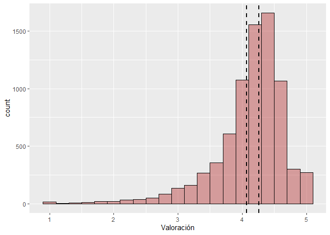

```r
ggplot(data = PlayStore) +
  aes(x = Valoración) +
  geom_histogram(binwidth = 0.2, col = 'black', fill = 'firebrick', alpha = 0.4) +
  geom_vline(xintercept = 4.07, linetype = "dashed", lwd = 1) +
  geom_vline(xintercept = 4.26, linetype = "dashed", lwd = 1)
```

> En este gráfico podemos ver la frecuencia de los datos reales y en las lineas punteadas el intervalo de confianza creado con nuestra muestra. Como vimos en el item 3 el IC creado con la muestra si contiene al promedio real.

> Notar que la varianza de la variable Valoracion es muy alta y tiene valores muy pequeños que pueden influir al calculo del promedio y si tengo una muestra no representativa podría caer en el 5% de casos que no contienen al promedio real.